# Red Wine Machine Learning Project

- Introduction
- Import Libraries
- Getting Data
- Data Exploration
- Data Preprocessing
- Building Machine Learning Models
- Evaluation
- Summary

# Introduction

This is an machine learning project classifying the quality of red wine as 'good' or 'bad'. The [data](https://archive.ics.uci.edu/ml/datasets/wine+quality) is from UC Irvine's Machine Learning Repository.

The data involves wine that are red variants of the Portuguese "Vinho Verde" wine is a unique product from the Minho region of Portugal. Vinho Verde wine typically has medium alcohol content and it particularly appreciatd due to its freshness. You can learn more about Vinho Verde wine by clicking [here](http://www.vinhoverde.pt/en/) Viho verde contains more normal wines than excellent or poor ones.

You can view the github repository [here](https://github.com/kchaaa/rw-ml-project).

[figure not shown]

# Import Libraries

```python
# Math
import numpy as np
import math

# Data Processing
import pandas as pd
from sklearn.model_selection import train_test_split

# Data Visualization
from matplotlib import pyplot as plt
import seaborn as sns

# Machine Learning Models
from sklearn.linear_model import LogisticRegression
from sklearn.discriminant_analysis import LinearDiscriminantAnalysis
from sklearn.ensemble import RandomForestClassifier
from sklearn.tree import DecisionTreeClassifier
from sklearn.neighbors import KNeighborsClassifier
from sklearn.svm import SVC
from sklearn.naive_bayes import GaussianNB

# Optimization
from sklearn.model_selection import GridSearchCV, cross_val_score

# Evaluation
from sklearn.metrics import accuracy_score, confusion_matrix, classification_report
from sklearn.metrics import roc_curve, roc_auc_score
```

# Getting Data

```python
# Read in data
file_path = '..\\data\\winequality-red.csv'
rw_data = pd.read_csv(file_path, sep=';')

# Change column names to follow convention
rw_data.columns = rw_data.columns.str.replace(" ", "_")
```

# Data Exploration

### Input Variables (based on physicochemical tests):

- **fixed_acidity:** most acids involved with wine or fixed or nonvolatile (do not evaporate readily)
  - Measured: tartaric acid - g / dm^3
- **volatile_acidity:** the amount of acetic acid in wine, which at too high of levels can lead to an unpleasant, vinegar taste
  - Measured: acetic acid - g / dm^3
- **citric_acid:** found in small quantities, citric acid can add 'freshness' and flavor to wines *(g)*
  - Measured: g / dm^3
- **residual_sugar:** the amount of sugar remaining after fermentation stops, it's rare to find wines with less than 1 gram/liter and wines with greater than 45 grams/liter are considered sweet
  - Measured: g / dm^3
- **chlorides:** the amount of salt in the wine
  - Measured: sodium chloride - g / dm^3
- **free_sulfur_dioxide:** the free form of SO2 exists in equilibrium between molecular SO2 (as a dissolved gas) and bisulfite ion; it prevents microbial growth and the oxidation of wine
  - Measured: mg / dm^3
- **total_sulfur_dioxide:** amount of free and bound forms of S02; in low concentrations, SO2 is mostly undetectable in wine, but at free SO2 concentrations over 50 ppm, SO2 becomes evident in the nose and taste of wine
  - Measured: mg / dm^3
- **density:** the density of water is close to that of water depending on the percent alcohol and sugar content
  - Measured: g / cm^3
- **pH:** describes how acidic or basic a wine is on a scale from 0 (very acidic) to 14 (very basic); most wines are between 3-4 on the pH scale
  - Measured: pH scale
- **sulphates:** a wine additive which can contribute to sulfur dioxide gas (S02) levels, wich acts as an antimicrobial and antioxidant
  - Measured: potassium sulphate - g / dm3
- **alcohol:** the percent alcohol content of the wine
  - Measured: % by volume

### Output Variable (based on sensory data):

- **quality:** based on sensory data
  - Measured: score between 0 and 10

All of these features seem important in determining the quality of wine.

```python
rw_data.info()
```

```
<class 'pandas.core.frame.DataFrame'>
RangeIndex: 1599 entries, 0 to 1598
Data columns (total 12 columns):
fixed_acidity           1599 non-null float64
volatile_acidity        1599 non-null float64
citric_acid             1599 non-null float64
residual_sugar          1599 non-null float64
chlorides               1599 non-null float64
free_sulfur_dioxide     1599 non-null float64
total_sulfur_dioxide    1599 non-null float64
density                 1599 non-null float64
pH                      1599 non-null float64
sulphates               1599 non-null float64
alcohol                 1599 non-null float64
quality                 1599 non-null int64
dtypes: float64(11), int64(1)
memory usage: 150.0 KB
```

**The data set has 1,599 examples and 11 features** (not including output variable quality). 11 of the features are doubles and the output variable is the only integer. Luckily, there is no character variables we need to convert.

Here is a brief description of each feature (and output variable):

```python
rw_data.describe()
```

|  | fixed_acidity | volatile_acidity | citric_acid | residual_sugar | chlorides | free_sulfur_dioxide | total_sulfur_dioxide | density | pH | sulphates | alcohol | quality |
| --- | --- | --- | --- | --- | --- | --- | --- | --- | --- | --- | --- | --- |
| count | 1599.000000 | 1599.000000 | 1599.000000 | 1599.000000 | 1599.000000 | 1599.000000 | 1599.000000 | 1599.000000 | 1599.000000 | 1599.000000 | 1599.000000 | 1599.000000 |
| mean | 8.319637 | 0.527821 | 0.270976 | 2.538806 | 0.087467 | 15.874922 | 46.467792 | 0.996747 | 3.311113 | 0.658149 | 10.422983 | 5.636023 |
| std | 1.741096 | 0.179060 | 0.194801 | 1.409928 | 0.047065 | 10.460157 | 32.895324 | 0.001887 | 0.154386 | 0.169507 | 1.065668 | 0.807569 |
| min | 4.600000 | 0.120000 | 0.000000 | 0.900000 | 0.012000 | 1.000000 | 6.000000 | 0.990070 | 2.740000 | 0.330000 | 8.400000 | 3.000000 |
| 25% | 7.100000 | 0.390000 | 0.090000 | 1.900000 | 0.070000 | 7.000000 | 22.000000 | 0.995600 | 3.210000 | 0.550000 | 9.500000 | 5.000000 |
| 50% | 7.900000 | 0.520000 | 0.260000 | 2.200000 | 0.079000 | 14.000000 | 38.000000 | 0.996750 | 3.310000 | 0.620000 | 10.200000 | 6.000000 |
| 75% | 9.200000 | 0.640000 | 0.420000 | 2.600000 | 0.090000 | 21.000000 | 62.000000 | 0.997835 | 3.400000 | 0.730000 | 11.100000 | 6.000000 |
| max | 15.900000 | 1.580000 | 1.000000 | 15.500000 | 0.611000 | 72.000000 | 289.000000 | 1.003690 | 4.010000 | 2.000000 | 14.900000 | 8.000000 |

As we can see, 'quality' ranges from 3-8 (on a scale of 1-10). On average, there is a lot of scores between 5 and 6 showing the data contains a lot more 'normal' wines than excellent or poor ones.

```python
rw_data.head(15)
```

|  | fixed_acidity | volatile_acidity | citric_acid | residual_sugar | chlorides | free_sulfur_dioxide | total_sulfur_dioxide | density | pH | sulphates | alcohol | quality |
| --- | --- | --- | --- | --- | --- | --- | --- | --- | --- | --- | --- | --- |
| 0 | 7.4 | 0.700 | 0.00 | 1.9 | 0.076 | 11.0 | 34.0 | 0.9978 | 3.51 | 0.56 | 9.4 | 5 |
| 1 | 7.8 | 0.880 | 0.00 | 2.6 | 0.098 | 25.0 | 67.0 | 0.9968 | 3.20 | 0.68 | 9.8 | 5 |
| 2 | 7.8 | 0.760 | 0.04 | 2.3 | 0.092 | 15.0 | 54.0 | 0.9970 | 3.26 | 0.65 | 9.8 | 5 |
| 3 | 11.2 | 0.280 | 0.56 | 1.9 | 0.075 | 17.0 | 60.0 | 0.9980 | 3.16 | 0.58 | 9.8 | 6 |
| 4 | 7.4 | 0.700 | 0.00 | 1.9 | 0.076 | 11.0 | 34.0 | 0.9978 | 3.51 | 0.56 | 9.4 | 5 |
| 5 | 7.4 | 0.660 | 0.00 | 1.8 | 0.075 | 13.0 | 40.0 | 0.9978 | 3.51 | 0.56 | 9.4 | 5 |
| 6 | 7.9 | 0.600 | 0.06 | 1.6 | 0.069 | 15.0 | 59.0 | 0.9964 | 3.30 | 0.46 | 9.4 | 5 |
| 7 | 7.3 | 0.650 | 0.00 | 1.2 | 0.065 | 15.0 | 21.0 | 0.9946 | 3.39 | 0.47 | 10.0 | 7 |
| 8 | 7.8 | 0.580 | 0.02 | 2.0 | 0.073 | 9.0 | 18.0 | 0.9968 | 3.36 | 0.57 | 9.5 | 7 |
| 9 | 7.5 | 0.500 | 0.36 | 6.1 | 0.071 | 17.0 | 102.0 | 0.9978 | 3.35 | 0.80 | 10.5 | 5 |
| 10 | 6.7 | 0.580 | 0.08 | 1.8 | 0.097 | 15.0 | 65.0 | 0.9959 | 3.28 | 0.54 | 9.2 | 5 |
| 11 | 7.5 | 0.500 | 0.36 | 6.1 | 0.071 | 17.0 | 102.0 | 0.9978 | 3.35 | 0.80 | 10.5 | 5 |
| 12 | 5.6 | 0.615 | 0.00 | 1.6 | 0.089 | 16.0 | 59.0 | 0.9943 | 3.58 | 0.52 | 9.9 | 5 |
| 13 | 7.8 | 0.610 | 0.29 | 1.6 | 0.114 | 9.0 | 29.0 | 0.9974 | 3.26 | 1.56 | 9.1 | 5 |
| 14 | 8.9 | 0.620 | 0.18 | 3.8 | 0.176 | 52.0 | 145.0 | 0.9986 | 3.16 | 0.88 | 9.2 | 5 |

Luckily, all of the features are numeric which means there won't be a need to convert them. However, we can see there is a wide range of numerical features which need to be grouped up. Especially for those like me who aren't really familiar with wine and how each feature impacts the quality of wine, it will require a lot of thinking in how to properly categorize it.

*(According to the description provided by the repository, there is no missing values to worry about handling.)*

### Data Visualization

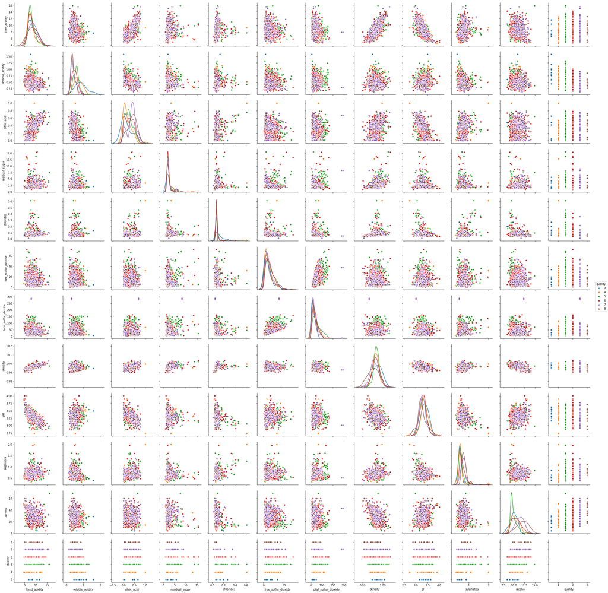

```python
# Pairplot
sns.pairplot(rw_data, hue = 'quality', diag_kind = 'kde')
```

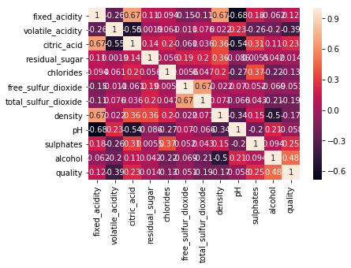

```python
# Correlation Matrix
correlation = rw_data.corr()
sns.heatmap(correlation,
            annot=True,
            xticklabels=correlation.columns.values,
            yticklabels=correlation.columns.values)
```

### Distribution

Based on the pairplot, it looks like all, but pH and density have distribution that is skewed right. Density and pH have a fairly normal distribution.

### Correlation

Features with a **strong positive correlation**(around +0.70):

- fixed_acidity and citric_acid
- fixed_acidity and density
- free_sulfur_dioxide and total_sulfur_dioxide

Features with a **strong negative correlation**(around -0.70):

- fixed_acidity and pH

Features with a **moderate positive correlation**(around +0.50):

- **alcohol and quality**

Features with a **moderate negative correlation**(around -0.50):

- citric_acid and volatile_acidity
- pH and citric acid
- density and alcohol

Features with a **weak positive correlation**(around +0.30):

- citric_acid and density
- citric_acid and sulphates

Features with a **weak negative correlation**(around -0.30):

- **volatile_acidity and quality**
- density and pH

Some of these relationships make sense like **free_sulfur_dioxide and total_sulfur_dioxide** and any relationship involving pH and acids (citric_acid, fixed_acidity). I do think it is interesting that volatile_acidity and pH have a weak relatioinship. However, I think two important relationships to highlight is the ones involving quality: **alcohol and quality** and **volatile_acidity and quality**. While **volatile_acidity and quality** has a weak relationship, it is still notable enough to keep in mind when I build my models.

# Data Preprocessing

I will try my best at feature engineering in order to help improve my models' performance when the time comes.

### Quality

Going forward, I want to categorize the quality of wine as 'good' and 'bad' instead of keeping it on a scale of 1-10. I feel it is reasonable to deem wine with a score of 7 or higher as 'good' and consider wine with a score less than 7 as 'bad'. By doing so, I will be able to make this more suited for a binary classifier.

```python
rw_data['quality'] = rw_data['quality'].mask(rw_data['quality'] < 7, 0)
rw_data['quality'] = rw_data['quality'].mask(rw_data['quality'] >= 7, 1)
```

### Fixed Acidity

After spending some time researching fixed acidity, I don't think there is a proper way of categorizing it based on the properties of fixed acidity. Due to it's wide range, I think I will use decile binning.

[Source](http://waterhouse.ucdavis.edu/whats-in-wine/fixed-acidity)

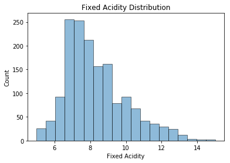

```python
# Function: Plot Histogram
def plot_hist(data, alpha, title, xlabel, ylabel) :
   bins = np.linspace(math.ceil(min(data)),
                   math.floor(max(data)),
                   20)
   plt.hist(data, bins=bins, alpha=alpha, edgecolor='black')

   plt.title(title)
   plt.xlabel(xlabel)
   plt.ylabel(ylabel)

   plt.show()

plot_hist(rw_data['fixed_acidity'], 0.5, 'Fixed Acidity Distribution', 'Fixed Acidity', 'Count')
```

```python
# 0 : D1 1 : D2	2 : D3	3 : D4	4 : D5	5 : D6	6 : D7	7 : D8	8 : D9	9 : D10
rw_data['fixed_acidity'] = pd.qcut(rw_data['fixed_acidity'], q=10, labels=[0, 1, 2, 3, 4, 5, 6, 7, 8, 9], precision=1.0)
```

### Volatile Acidity

The amount of volatile acidity doesn't seem to have an effect on the taste of wine. The amount present is negible. However, we did learn there is a notable (but weak) relationship with quality. Like with fixed acidity, I will also use decile binning.

[Source](http://waterhouse.ucdavis.edu/whats-in-wine/volatile-acidity)

```python
rw_data['volatile_acidity'].describe()
```

```
count    1599.000000
mean        0.527821
std         0.179060
min         0.120000
25%         0.390000
50%         0.520000
75%         0.640000
max         1.580000
Name: volatile_acidity, dtype: float64
```

```python
# 0 : D1 1 : D2	2 : D3	3 : D4	4 : D5	5 : D6	6 : D7	7 : D8	8 : D9	9 : D10
rw_data['volatile_acidity'] = pd.qcut(rw_data['volatile_acidity'], q=10,
									  labels=[0, 1, 2, 3, 4, 5, 6, 7, 8, 9], precision=1.0)
```

### Citric Acid

Citric acid is used to increase the acidity which does show the strong relationship with pH. However, there is no "proper" way of categorizing, so I will use quantile binning because the min is 0 and max is 1.

[Source](http://wineserver.ucdavis.edu/industry/enology/methods_and_techniques/reagents/citric_acid.html)

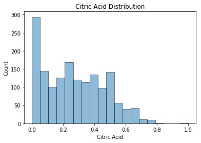

```python
plot_hist(rw_data['citric_acid'], 0.5, 'Citric Acid Distribution', 'Citric Acid', 'Count')
```

```python
# 0 : Q1		1 : Q2		2 : Q3		3 : Q4
rw_data['citric_acid'] = pd.qcut(rw_data['citric_acid'], q=4, labels=[0, 1, 2, 3], precision=1.0)
```

### Residual Sugar

Residual sugar refers to the amount of sugar remaining after fermentation stops. The amount of sugar is what classifies alcohol as "dry" or "sweet" as we see with other alcoholic drinks such as cider or sake. Because of this, we want to classify the wine based on the amount of sugar using this chart:

[Source](http://www.desizeme.com/Residual-Sugar-in-Wine-Sweetness-Chart-Calories-in-Wine.html)

[figure not shown]

```python
rw_data['residual_sugar'] = rw_data['residual_sugar'].mask(rw_data['residual_sugar'] < 1, 0)
rw_data['residual_sugar'] = rw_data['residual_sugar'].mask((rw_data['residual_sugar'] >= 1) & (rw_data['residual_sugar'] <= 10), 1)
rw_data['residual_sugar'] = rw_data['residual_sugar'].mask(rw_data['residual_sugar'] > 10, 2)
```

### Chlorides

The amount of chlorides present doesn't have an effect on wine. I will be going with quantile binning.

```python
rw_data['chlorides'].describe()
```

```
count    1599.000000
mean        0.087467
std         0.047065
min         0.012000
25%         0.070000
50%         0.079000
75%         0.090000
max         0.611000
Name: chlorides, dtype: float64
```

```python
# 0 : Q1		1 : Q2		2 : Q3		3 : Q4
rw_data['chlorides'] = pd.qcut(rw_data['chlorides'], q=4, labels=[0, 1, 2, 3], precision=1.0)
```

### Free Sulfur Dioxide

The level of free sulfur dioxide required to protect wine are pH-dependent. Free sulfur dioxide and pH are positively correlated: as pH goes up, there needs to be higher levels of free sulfur dioxide to protect the wine. A general rule seems to be: You need 50 ppm of Free Sulfur Dioxide with a pH level of 3.6 for adequate protection purposes. From there, +/- 10 ppm for every +/- 0.1 pH level respectively. To bin this, I will divide the feature into 2: those that follow the rule and those that do not.

[Source](http://morewinemaking.com/public/pdf/so2.pdf)

```python
rw_data['free_sulfur_dioxide'] = rw_data['free_sulfur_dioxide'].mask((rw_data['pH'] >= 3.9) &
																(rw_data['free_sulfur_dioxide'] >= 92), 1)
rw_data['free_sulfur_dioxide'] = rw_data['free_sulfur_dioxide'].mask((rw_data['pH'] >= 3.8) & (rw_data['pH'] < 3.9) &
																(rw_data['free_sulfur_dioxide'] >= 78) & (rw_data['free_sulfur_dioxide'] < 92), 1)
rw_data['free_sulfur_dioxide'] = rw_data['free_sulfur_dioxide'].mask((rw_data['pH'] >= 3.7) & (rw_data['pH'] < 3.8) &
																(rw_data['free_sulfur_dioxide'] >= 64) & (rw_data['free_sulfur_dioxide'] < 78), 1)
rw_data['free_sulfur_dioxide'] = rw_data['free_sulfur_dioxide'].mask((rw_data['pH'] >= 3.8) & (rw_data['pH'] < 3.9) &
																(rw_data['free_sulfur_dioxide'] >= 50) & (rw_data['free_sulfur_dioxide'] < 64), 1)
rw_data['free_sulfur_dioxide'] = rw_data['free_sulfur_dioxide'].mask((rw_data['pH'] >= 3.7) & (rw_data['pH'] < 3.8) &
																(rw_data['free_sulfur_dioxide'] >= 40) & (rw_data['free_sulfur_dioxide'] < 50), 1)
rw_data['free_sulfur_dioxide'] = rw_data['free_sulfur_dioxide'].mask((rw_data['pH'] >= 3.8) & (rw_data['pH'] < 3.9) &
																(rw_data['free_sulfur_dioxide'] >= 31) & (rw_data['free_sulfur_dioxide'] < 40), 1)
rw_data['free_sulfur_dioxide'] = rw_data['free_sulfur_dioxide'].mask((rw_data['pH'] >= 3.7) & (rw_data['pH'] < 3.8) &
																(rw_data['free_sulfur_dioxide'] >= 27) & (rw_data['free_sulfur_dioxide'] < 31), 1)
rw_data['free_sulfur_dioxide'] = rw_data['free_sulfur_dioxide'].mask((rw_data['pH'] >= 3.8) & (rw_data['pH'] < 3.9) &
																(rw_data['free_sulfur_dioxide'] >= 21) & (rw_data['free_sulfur_dioxide'] < 27), 1)
rw_data['free_sulfur_dioxide'] = rw_data['free_sulfur_dioxide'].mask((rw_data['pH'] >= 3.7) & (rw_data['pH'] < 3.8) &
																(rw_data['free_sulfur_dioxide'] >= 17) & (rw_data['free_sulfur_dioxide'] < 21), 1)
rw_data['free_sulfur_dioxide'] = rw_data['free_sulfur_dioxide'].mask((rw_data['pH'] >= 3.8) & (rw_data['pH'] < 3.9) &
																(rw_data['free_sulfur_dioxide'] >= 12) & (rw_data['free_sulfur_dioxide'] < 17), 1)
rw_data['free_sulfur_dioxide'] = rw_data['free_sulfur_dioxide'].mask((rw_data['pH'] < 3.0) &
																(rw_data['free_sulfur_dioxide'] < 12), 1)
rw_data['free_sulfur_dioxide'] = rw_data['free_sulfur_dioxide'].mask(rw_data['free_sulfur_dioxide'] != 1, 0)
```

### Total Sulfur Dioxide

Due to the strong relationship of "free_sulfur_dioxide and total_sulfur_dioxide", I feel categorizing this feature based off free_sulfur_dioxide seems reasonable. Basically, any free_sulfur_dioxide with 1 will have a total_sulfur_dioxide of 1 and the same goes for 0.

```python
rw_data['total_sulfur_dioxide'] = rw_data['total_sulfur_dioxide'].mask(rw_data['free_sulfur_dioxide'] == 0, 0)
rw_data['total_sulfur_dioxide'] = rw_data['total_sulfur_dioxide'].mask(rw_data['free_sulfur_dioxide'] == 1, 1)
```

### Density

The amount of density present doesn't have an effect on wine. I will be going with quantile binning.

```python
rw_data['density'].describe()
```

```
count    1599.000000
mean        0.996747
std         0.001887
min         0.990070
25%         0.995600
50%         0.996750
75%         0.997835
max         1.003690
Name: density, dtype: float64
```

```python
# 0 : Q1		1 : Q2		2 : Q3		3 : Q4
rw_data['density'] = pd.qcut(rw_data['density'], q=4, labels=[0, 1, 2, 3], precision=1.0)
```

### pH

On average, wine has a pH level between 3.3-3.6. Any wine >3.6 is considered less acidic than average and any wine <3.3 is considered more acidic than average.

[Source](http://winefolly.com/review/understanding-acidity-in-wine/)

```python
rw_data['pH'] = rw_data['pH'].mask(rw_data['pH'] > 3.6, 2)
rw_data['pH'] = rw_data['pH'].mask(rw_data['pH'] >= 3.3, 1)
rw_data['pH'] = rw_data['pH'].mask(rw_data['pH'] < 3.3, 0)
```

### Sulphates

The amount of sulphates present doesn't have an effect on wine. I will be going with quantile binning.

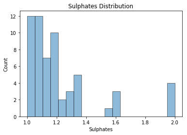

```python
plot_hist(rw_data['sulphates'], 0.5, 'Sulphates Distribution', 'Sulphates', 'Count')
```

```python
# 0 : Q1		1 : Q2		2 : Q3		3 : Q4
rw_data['sulphates'] = pd.qcut(rw_data['sulphates'], q=4, labels=[0, 1, 2, 3], precision=1.0)
```

### Alcohol

On average, wine has an ABV of around 12-15%. I will divide this feature based on the infographic below (except High Alcohol (>15%) because looking at the distribution, there is no wine with alcohol content above 15 present):

- **Low Alcohol**: <10%
- **Medium-Low Alcohol**: 10-11.5%
- **Medium Alcohol**: 11.5-13.5%
- **Medium-High Alcohol**: 13.5-15%

[Source](https://winefolly.com/tutorial/the-lightest-to-the-strongest-wine/)

[figure not shown]

```python
rw_data['alcohol'] = rw_data['alcohol'].mask(rw_data['alcohol'] < 10, 0)
rw_data['alcohol'] = rw_data['alcohol'].mask((rw_data['alcohol'] >= 10) & (rw_data['alcohol'] < 11.5), 1)
rw_data['alcohol'] = rw_data['alcohol'].mask((rw_data['alcohol'] >= 11.5) & (rw_data['alcohol'] < 13.5), 2)
rw_data['alcohol'] = rw_data['alcohol'].mask(rw_data['alcohol'] >= 13.5, 3)
```

### Final Look

```python
rw_data.head(20)
```

|  | fixed_acidity | volatile_acidity | citric_acid | residual_sugar | chlorides | free_sulfur_dioxide | total_sulfur_dioxide | density | pH | sulphates | alcohol | quality |
| --- | --- | --- | --- | --- | --- | --- | --- | --- | --- | --- | --- | --- |
| 0 | 3 | 8 | 0 | 1.0 | 1 | 0.0 | 0.0 | 2 | 0.0 | 1 | 0.0 | 0 |
| 1 | 4 | 9 | 0 | 1.0 | 3 | 0.0 | 0.0 | 2 | 0.0 | 2 | 0.0 | 0 |
| 2 | 4 | 9 | 0 | 1.0 | 3 | 0.0 | 0.0 | 2 | 0.0 | 2 | 0.0 | 0 |
| 3 | 9 | 0 | 3 | 1.0 | 1 | 0.0 | 0.0 | 3 | 0.0 | 1 | 0.0 | 0 |
| 4 | 3 | 8 | 0 | 1.0 | 1 | 0.0 | 0.0 | 2 | 0.0 | 1 | 0.0 | 0 |
| 5 | 3 | 7 | 0 | 1.0 | 1 | 0.0 | 0.0 | 2 | 0.0 | 1 | 0.0 | 0 |
| 6 | 4 | 6 | 0 | 1.0 | 0 | 0.0 | 0.0 | 1 | 0.0 | 0 | 0.0 | 0 |
| 7 | 3 | 7 | 0 | 1.0 | 0 | 0.0 | 0.0 | 0 | 0.0 | 0 | 1.0 | 1 |
| 8 | 4 | 6 | 0 | 1.0 | 1 | 0.0 | 0.0 | 2 | 0.0 | 1 | 0.0 | 1 |
| 9 | 3 | 4 | 2 | 1.0 | 1 | 0.0 | 0.0 | 2 | 0.0 | 3 | 1.0 | 0 |
| 10 | 1 | 6 | 0 | 1.0 | 3 | 0.0 | 0.0 | 1 | 0.0 | 0 | 0.0 | 0 |
| 11 | 3 | 4 | 2 | 1.0 | 1 | 0.0 | 0.0 | 2 | 0.0 | 3 | 1.0 | 0 |
| 12 | 0 | 7 | 0 | 1.0 | 2 | 0.0 | 0.0 | 0 | 0.0 | 0 | 0.0 | 0 |
| 13 | 4 | 6 | 2 | 1.0 | 3 | 0.0 | 0.0 | 2 | 0.0 | 3 | 0.0 | 0 |
| 14 | 6 | 7 | 1 | 1.0 | 3 | 0.0 | 0.0 | 3 | 0.0 | 3 | 0.0 | 0 |
| 15 | 6 | 7 | 1 | 1.0 | 3 | 0.0 | 0.0 | 3 | 0.0 | 3 | 0.0 | 0 |
| 16 | 6 | 0 | 3 | 1.0 | 3 | 0.0 | 0.0 | 2 | 0.0 | 3 | 1.0 | 1 |
| 17 | 5 | 5 | 2 | 1.0 | 3 | 0.0 | 0.0 | 2 | 0.0 | 3 | 0.0 | 0 |
| 18 | 3 | 6 | 0 | 1.0 | 2 | 0.0 | 0.0 | 2 | 0.0 | 0 | 0.0 | 0 |
| 19 | 4 | 1 | 3 | 1.0 | 3 | 0.0 | 0.0 | 2 | 0.0 | 3 | 0.0 | 0 |

# Building Machine Learning Models

### Splitting Data

```python
# Prediction Target
Y = rw_data["quality"]

# Predictors
X = rw_data.drop("quality", axis=1)

# Split into training and validation data sets
X_train, X_val, Y_train, Y_val = train_test_split(X, Y, random_state=0)
```

### Testing and Cross Validation

I will be using the following machine learning models:

- Gaussian Naive Bayes (NB)
- Logistic Regression (LR)
- Linear Discriminant Analysis (LDA)
- Support Vector Machines (SVM)
- K-Nearest Neighbors (KNN)
- Decision Tree (DT)
- Random Forest (RF)

I think this is a good mixture of simple linear (LR, LDA) and nonlinear (NB, SVM, KNN, DT, RF) algorithms.

```python
# Gaussian Naive Bayes
# Define Model
naive_bayes = GaussianNB()
# Score
naive_bayes_scores = cross_val_score(naive_bayes, X_train, Y_train, cv=10, scoring="accuracy")
# Print
print("Naive Bayes Cross-validation Scores:", naive_bayes_scores)
print("Mean:", naive_bayes_scores.mean())
print("Standard Deviation:", naive_bayes_scores.std())
```

```
Naive Bayes Cross-validation Scores: [0.24793388 0.28099174 0.35833333 0.25       0.38333333 0.325
 0.325      0.32773109 0.32773109 0.32773109]
Mean: 0.31537855638123025
Standard Deviation: 0.04136599720058937
```

```python
# Logistic Regression
# Define Model
log_reg = LogisticRegression()
# Score
log_reg_scores = cross_val_score(log_reg, X_train, Y_train, cv=10, scoring="accuracy")
# Print
print("Logistic Regression Cross-validation Scores:", log_reg_scores)
print("Mean:", log_reg_scores.mean())
print("Standard Deviation:", log_reg_scores.std())
```

```
Logistic Regression Cross-validation Scores: [0.85950413 0.88429752 0.875      0.85833333 0.84166667 0.89166667
 0.89166667 0.88235294 0.91596639 0.87394958]
Mean: 0.8774403893788921
Standard Deviation: 0.01986169480029738
```

```python
# Linear Discriminant Analysis
# Define Model
lin_da = LinearDiscriminantAnalysis()
# Score
lin_da_scores = cross_val_score(lin_da, X_train, Y_train, cv=10, scoring="accuracy")
# Print
print("Linear Discriminant Analysis Cross-validation Scores:", lin_da_scores)
print("Mean:", lin_da_scores.mean())
print("Standard Deviation:", lin_da_scores.std())
```

```
Linear Discriminant Analysis Cross-validation Scores: [0.85950413 0.87603306 0.875      0.86666667 0.83333333 0.89166667
 0.875      0.89915966 0.8907563  0.88235294]
Mean: 0.8749472764312337
Standard Deviation: 0.017917898406862455
```

```python
# Support Vector Machines
# Define Model
svm = SVC()
# Score
svm_scores = cross_val_score(svm, X_train, Y_train, cv=10, scoring="accuracy")
# Print
print("Support Vector Machines Cross-validation Scores:", svm_scores)
print("Mean:", svm_scores.mean())
print("Standard Deviation:", svm_scores.std())
```

```
Support Vector Machines Cross-validation Scores: [0.82644628 0.87603306 0.85       0.85       0.88333333 0.89166667
 0.86666667 0.89915966 0.8907563  0.8907563 ]
Mean: 0.8724818274417206
Standard Deviation: 0.022454391710208303
```

```python
# KNN
# Define Model
knn = KNeighborsClassifier(n_neighbors=3)
# Score
knn_scores = cross_val_score(knn, X_train, Y_train, cv=10, scoring="accuracy")
# Print
print("KNN Cross-validation Scores:", knn_scores)
print("Mean:", knn_scores.mean())
print("Standard Deviation:", knn_scores.std())
```

```
KNN Cross-validation Scores: [0.84297521 0.79338843 0.85833333 0.825      0.80833333 0.875
 0.86666667 0.8487395  0.88235294 0.83193277]
Mean: 0.8432722179781005
Standard Deviation: 0.0274037347695728
```

```python
# Decision Tree
# Define Model
dec_tree = DecisionTreeClassifier()
# Score
dec_tree_scores = cross_val_score(dec_tree, X_train, Y_train, cv=10, scoring="accuracy")
# Print
print("Decision Tree Cross-validation Scores:", dec_tree_scores)
print("Mean:", dec_tree_scores.mean())
print("Standard Deviation:", dec_tree_scores.std())
```

```
Decision Tree Cross-validation Scores: [0.83471074 0.81818182 0.875      0.88333333 0.86666667 0.83333333
 0.84166667 0.8487395  0.87394958 0.84033613]
Mean: 0.8515917772067505
Standard Deviation: 0.02061672417220868
```

```python
# Random Forest
# Define Model
rand_forest = RandomForestClassifier(n_estimators=100)
# Score
rand_forest_scores = cross_val_score(rand_forest, X_train, Y_train, cv=10, scoring="accuracy")
# Print
print("Random Forest Cross-validation Scores:", rand_forest_scores)
print("Mean:", rand_forest_scores.mean())
print("Standard Deviation:", rand_forest_scores.std())
```

```
Random Forest Cross-validation Scores: [0.87603306 0.81818182 0.9        0.875      0.89166667 0.9
 0.9        0.8907563  0.90756303 0.86554622]
Mean: 0.8824747088918212
Standard Deviation: 0.02494278193406906
```

```python
# Results
# Create Table Showing Best One
ml_scores = pd.DataFrame({
    'Model': ['Naive Bayes', 'Logistic Regression', 'Linear Discriminant Analysis', 'Support Vector Machines',
              'K-Nearest Neighbors', 'Random Forest', 'Decision Tree'],
    'Avg Score': [naive_bayes_scores.mean(), log_reg_scores.mean(), lin_da_scores.mean(), svm_scores.mean(),
                  knn_scores.mean(), rand_forest_scores.mean(),  dec_tree_scores.mean()],
    'SD': [naive_bayes_scores.std(), log_reg_scores.std(), lin_da_scores.std(), svm_scores.std(), knn_scores.std(),
           rand_forest_scores.std(),  dec_tree_scores.std()]
    })
# Sort by Highest Score => Lowest Score
ml_scores_df = ml_scores.sort_values(by=['Avg Score', 'Model', 'SD'], ascending=False)
ml_scores_df = ml_scores_df.set_index('Model')
print(ml_scores_df)
```

```
                              Avg Score        SD
Model
Random Forest                  0.882475  0.024943
Logistic Regression            0.877440  0.019862
Linear Discriminant Analysis   0.874947  0.017918
Support Vector Machines        0.872482  0.022454
Decision Tree                  0.851592  0.020617
K-Nearest Neighbors            0.843272  0.027404
Naive Bayes                    0.315379  0.041366
```

Overall, Random Forest yielded the best cross-validation score of **88.25%** with a standard deviation of **2.49%**. From here on out, I will be focusing on Random Forest and optimizing it to give the best results.

### Best Model: Random Forest

**Random Forest** is a supervised learning algorithm which is essentially a mixture of a bunch of Decision Trees or a "Forest of Decision Trees" if you will. Random forest builds multiple decision trees and merges them together to get a more accurate and stable prediction. This algorithm brings extra randomness into model due to the multiple trees. Instead of searching for the best feature while splitting a node, it searches for the best feature among a random subset of features. You can even make trees more random, by using random thresholds on top of it for each feature rather than searching for the best possible thresholds like a normal decision tree does. Random Forest can be tuned and optimized to yield a more accurate score.

[figure not shown]

```python
# Random Forest
rand_forest = RandomForestClassifier(n_estimators=100)
rand_forest.fit(X_train, Y_train)
Y_pred = rand_forest.predict(X_val)
acc_rand_forest = accuracy_score(Y_val, Y_pred) * 100
print("Random Forest Accuracy Score: ", round(acc_rand_forest, 2,), "%")
```

```
Random Forest Accuracy Score:  90.0 %
```

By executing a normal validation test, we can see that Random Forest yields an accuracy score of **90.0%**! This is very high, but let's see if we can make it more accurate.

### Feature Importance

One great quality of Random Forest is **Importance Feature** which helps see which features are relatively more important. We can use this quality to drop the less important features to give a better accuracy score. The general rule of thumb is that the more features you have, the more likely the model will suffer from overfitting.

```python
importance = pd.DataFrame({'feature':X_train.columns,'importance':np.round(rand_forest.feature_importances_,3)})
importance = importance.sort_values('importance',ascending=False).set_index('feature')
```

```python
importance.head(15)
```

| feature | importance |
| --- | --- |
| volatile_acidity | 0.228 |
| fixed_acidity | 0.174 |
| alcohol | 0.164 |
| sulphates | 0.128 |
| chlorides | 0.103 |
| density | 0.103 |
| citric_acid | 0.090 |
| total_sulfur_dioxide | 0.004 |
| residual_sugar | 0.003 |
| free_sulfur_dioxide | 0.003 |
| pH | 0.000 |

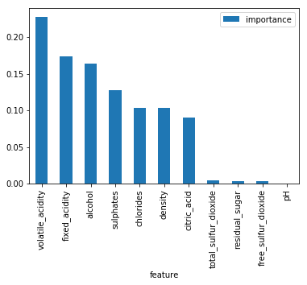

```python
importance.plot.bar()
```

As we can see, residual_sugar, free_sulfur_dioxide, total_sulfur_dioxide, and pH have little to no importance to Random Forest. Let's drop these features and see if it improves our model.

```python
# Drop Less Important Feature
rw_data = rw_data.drop('residual_sugar', axis=1)
rw_data = rw_data.drop('free_sulfur_dioxide', axis=1)
rw_data = rw_data.drop('total_sulfur_dioxide', axis=1)
rw_data = rw_data.drop('pH', axis=1)

#Training Random Forest Again
Y = rw_data["quality"]
X = rw_data.drop("quality", axis=1)
X_train, X_val, Y_train, Y_val = train_test_split(X, Y, random_state=0)

rand_forest = RandomForestClassifier(n_estimators=100, oob_score=True)
rand_forest.fit(X_train, Y_train)
Y_pred = rand_forest.predict(X_val)
acc_rand_forest = accuracy_score(Y_val, Y_pred) * 100
print("Random Forest Accuracy Score: ", round(acc_rand_forest, 2,), "%")
```

```
Random Forest Accuracy Score:  89.25 %
```

The accuracy score decreased, but not enough to worry about. It might mean it possibly decreased overfitting. For Random Forest, more features usually lead to overfitting, so getting rid of those 4 features is probably for the best.

### Out-of-bag Error

Another way we can evaluate Random Forest is by using **Out-of-bag Error** which, to put it simply, is as accurate as using a validation set of the same size as the training set.

```python
print("out-of-bag score:", round(rand_forest.oob_score_, 3)*100, "%")
```

```
out-of-bag score: 88.2 %
```

#### Hyperparameter Tuning

Another nice quality of Random Forest is **Hyperparameter Tuning**. This is the ability to adjust the parameters in order to optimize the performance of the algorithm. Some parameters are made during training, but hyperparameters can be adjusted before training. I will be tuning the following parameters:

- **criterion**: measure of the quality of the split: “gini”(indicator of how messy the data is) or “entropy”(measure of misclassification)
- **max_features**: max number of features considered for splitting a node
- **n_estimators**: number of trees in the foreset
- **max_depth**: max number of levels in each decision tree
- **min_samples_leaf**: min number of data points placed in a node before the node is split
- **min_samples_split**: min number of data points allowed in a leaf node

I will use **GridSearchCV()** to evaluate which are the best hyperparameters to use.

```python
# Create the parameter grid based on the results of random search
param_grid = {
    "criterion" : ["gini", "entropy"],
    'max_features': ['auto', 'sqrt'],
    'n_estimators': [100, 200, 300, 1000],
    'max_depth': [80, 90, 100, 110],
    'min_samples_leaf': [1, 5, 10, 25, 50, 70],
    'min_samples_split': [2, 4, 10, 12, 16, 18, 25, 35]
}
```

Due to the long run-time, I won't be actually executing the code. I commented in the code I used and showed a screenshot of the result I achieved in a python IDE known as PyCharm.

```python
# rf = RandomForestClassifier(oob_score=True, random_state=1, n_jobs=-1)
# clf = GridSearchCV(estimator=rf, param_grid=param_grid, n_jobs=-1)
# clf.fit(X_train, Y_train)
# clf.best_params_
```

[figure not shown]

Now I will use the paramters mentioned above to improve my out-of-bag score.

```python
# Random Forest (with best hyperparameters)
rand_forest = RandomForestClassifier(criterion="entropy",
                                     max_depth=80,
                                     max_features='auto',
                                     min_samples_leaf=1,
                                     min_samples_split=2,
                                     n_estimators=200,
                                     oob_score=True,
                                     random_state=1,
                                     n_jobs=-1)
rand_forest.fit(X_train, Y_train)
Y_pred= rand_forest.predict(X_val)
rand_forest.score(X_train, Y_train)
print("out-of-bag score:", round(rand_forest.oob_score_, 3)*100, "%")
```

```
out-of-bag score: 88.2 %
```

The score stayed the same which isn't bad. I was hoping to see an increase, but at least there wasn't a decrease.

# Evaluation

Now that I have a more properly tuned model, I can start evaluating its performance even further using Confusion Matrix, Classification Report, and ROC AUC Curve. which are typically used to evaluate the algorithm's prediction results.

### Confusion Matrix

**Confusion Matrix** presents an accuracy of the model showing True Positive, True Negative, False Positive, and False Negative.

```python
confusion_matrix(Y_val, Y_pred)
```

```
array([[330,  25],
       [ 16,  29]], dtype=int64)
```

### Classification Report (Precision, Recall, F1 Score)

**Classification Report** displays the precision, recall, f1-score, and support for each class. It gives a quick idea of accuracy using number of errors. (*Reminder: 0 = bad quality 1 = good quality wine*)

- **Precision**: how often it correctly Predicted Good
- **Recall**: how often Actual Good = Predicted Good
- **F1-score**: weighted average of Precision and Recall (depends on Precision and Recall scores)
- **Support**: number of samples for both that exist

```python
class_report = classification_report(Y_val, Y_pred)
print(class_report)
```

```
             precision    recall  f1-score   support

          0       0.95      0.93      0.94       355
          1       0.54      0.64      0.59        45

avg / total       0.91      0.90      0.90       400
```

The model correctly classified **95%** as bad (Precision) with a Recall score of **93%**. With high Precision and Recall score, it is no surprise the F1-score is **94%**. The model correctly classified **54%** as good (Precision) with a Recall score of **64%**. With a moderate Precision and Recall score, it is no surprise the F1-score is **59%**.

Overall, the model did a better job of classifying bad quality wines than it did for good quality wines. However, I believe this is so due to the fact that there were only 45 examples of good quality wines while there are 355 examples of bad quality wines. However, this is also due to the fact that there were more "normal" wines included in this data set as mentioned earlier which included a lot more 5s and 6s than any other score. Since, I classified "good" as 7 or higher, this means there were less examples of good quality wine included in the data set.

### ROC AUC Curve

Another way to evaluate and compare this binary classifier is the **ROC AUC Curve**. This curve plots the true positive rate (Recall) against the false positive rate. In the plot, the red line in the middle represents a purely random classifier meaning the blue curve (my classifier) should be as far away from the red line as possible.

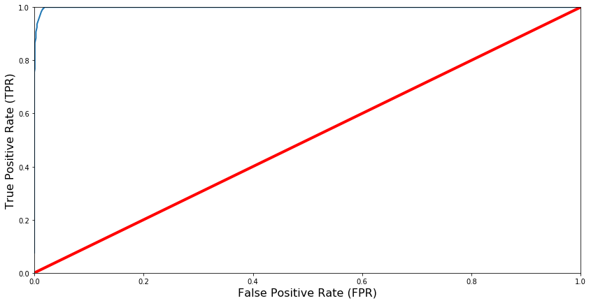

```python
# Getting the probabilities of our predictions
y_scores = rand_forest.predict_proba(X_train)
y_scores = y_scores[:,1]

# Calculate False Positive and True Positive
false_positive_rate, true_positive_rate, thresholds = roc_curve(Y_train, y_scores)

# Function: Plotting False Positive against True Positive
def plot_roc_curve(false_positive_rate, true_positive_rate, label=None) :
    plt.plot(false_positive_rate, true_positive_rate, linewidth=2, label=label)
    plt.plot([0, 1], [0, 1], 'r', linewidth=4)
    plt.axis([0, 1, 0, 1])
    plt.xlabel('False Positive Rate (FPR)', fontsize=16)
    plt.ylabel('True Positive Rate (TPR)', fontsize=16)

plt.figure(figsize=(14, 7))
plot_roc_curve(false_positive_rate, true_positive_rate)
plt.show()
```

As we can barely see the blue line, it means the model did a really good job.

### ROC AUC Score

The ROC AUC Score is the corresponding score to the ROC AUC Curve. It is simply computed by measuring the Area Under the Curve (AUC). Maybe knowing the numerical score of the ROC AUC Curve will help us understand the lack of a blue line present in the plot.

```python
r_a_score = roc_auc_score(Y_train, y_scores)
print("ROC AUC-Score:", r_a_score)
```

```
ROC AUC-Score: 0.9989979846470868
```

With a ROC AUC score of almost **100%** (99.90%), I can see why there is barely a blue line present.

# Summary

### Analysis-Features Affecting Quality

When we explored the data, we noticed a weak negative correlation between **quality and volatile_acidity**. This means that the more volatile acidity present in the red wine, then there will be slight decrease in the percetion of quality. We also noticed a moderate positive correlation between **quality and alcohol**. This means the higher the ABV levels, there will be a moderate increase in the perception of quality. In fact, we can see how true the correlation is by looking at the feature importance of our best performing machine learning model, Random Forest.

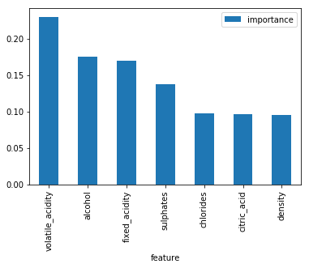

```python
importance = pd.DataFrame({'feature':X_train.columns,'importance':np.round(rand_forest.feature_importances_,3)})
importance = importance.sort_values('importance',ascending=False).set_index('feature')
importance.plot.bar()
```

Looking at the histogram above, we see that the two most important features on predicting quality is first volatile_acidity and then alcohol.

I can understand why a decrease in volatile acidity could affect quality. The more volatile acidity in wine, the more present the unpleasant vinegar taste you might find in some wine. This means less wouldn't give the unpleasant vinegar taste. I kind of understand the the positive correlation between alcohol and quality because some people like to drink alcoholic beverages with more alcohol present. However, this one may be one of the more subjective features because this mainly boils down to individual's preference.

### Analysis-Features Dropped

I want to take a moment to look back at the features we dropped while optimizing our model: residual_sugar, free_sulfur_dioxide, total_sulfur_dioxide, and pH. These were 4 out of 5 features we could actually categorize properly (5th being alcohol.) Looking back at the pairplots and heatmap, these 4 features did not really have any correlation with quality to begin with.

I was surprised these features were dropped due to my initial beliefs regarding their effect on quality. For residual sugar, I thought people would care if wine was dry or sweet. For free sulfur dioxide and total sulfur dioxide, I learned the importance of properly the exact amount of free sulfur dioxide needed based on the levels of pH present. I categorized the feature depending on whether the wine followed these exact rules. For pH, I was surprised because I thought how acidic or basic the wine was would potentially affect the perception of quality. However, this one is not as bad to omit because there are three other features that affect the acidic levels that arguably do a better job at telling the story.

### Conclusion

In conclusion, it seems the amount of (or lack of) vinegar taste and ABV levels have the most effect on perception of quality for red wine. My model did a good job of correctly classifying the bad quality wines while only being able to correctly classify a little over half of the good quality wines. However, I would like to point out the fact that the data set mainly contained "normal" wines (or wines with scores of 5-6.) This meant the data set mainly contained bad quality wines. Also, the lack of data could have had an effect on feature importance because it could have been an overwhelming dominance of one category which would have the model deem these features unnecessary and drop them. This is something to look into moving forward.

### Personal Reflection

While doing this project over the past few days, I learned a lot about data-related projects (which is the main purpose of these types of projects for me anyways.) I finally understand the **importance of data cleaning and preprocessing**. These steps in a data-related project are to me the most important, work-intensive, and frustrating aspects of doing the project. It felt like 80% of the work came from these steps. It would have been a lot easier if I were to have done a project related to what I already knew about. However, I just conducted a lot of research and learned more about the scientific aspects of wine than I would ever imagined learning in my whole life. I wouldn't let my lack of knowledge stop me from going forward with this project.

I learned that having more knowledge about the topic especially helps with understanding the data and feature engineering. I learned that taking the time to understand the more conceptual aspects of the project is possibly as important as doing the hands-on aspects aka coding. It is something that I will keep in mind as I do more data-related work in the future. I learned the complexity of feature engineering because sometimes it is hard to determine what the proper way of doing so is.

If I were to do the project again, I would include more data, esepcially the inclusion of more poor and excellent wines. I would also (hopefully) be more proficient at feature engineering.

Doing this project did give me a deeper learning about machine learning than any book, classroom, or online course has given me in the past month of learning. This project also improved my python coding ability by allowing me to learn the syntax of popular libraries such as pandas and scikit-learn better. My previous experience with data-related work mainly focused on R at school and my past job as a junior research assistant. This project helped improve my data cleaning, data analysis, and python skills. I also now have a better understanding of how to potentially report the results of data anlysis.

Thank you to those who took the time to look over my first machine learning project! I plan on doing more in the future and hopefully each project will get better and better from here on out.